# GOfuncR: Gene Ontology Enrichment Using FUNC

Steffi Grote

October 13, 2017

# 1 Overview

*GOfuncR* performs a gene ontology enrichment analysis based on the ontology enrichment software FUNC [1,2]. It provides the standard candidate vs. background enrichment analysis using the hypergeometric test, as well as three additional tests: (i) the Wilcoxon rank-sum test that is used when genes are ranked, (ii) a binomial test that can be used when genes are associated with two counts, e.g. amino acid changes since a common ancestor in two different species, and (iii) a Chi-square or Fisher’s exact test that is used in cases when genes are associated with four counts, e.g. non-synonymous or synonymous variants that are fixed between or variable within species.  
To correct for multiple testing and interdependency of the tests, family-wise error rates (FWER) are computed based on random permutations of the gene-associated variables (see Schematic 1 below). *GOfuncR* also provides tools for exploring the ontology graph and the annotations, and options to take gene-length or spatial clustering of genes into account during testing.  
GO-annotations are obtained from *OrganismDb* or *OrgDb* packages (*Homo.sapiens* by default). The gene ontology graph (obtained from [geneontology](http://archive.geneontology.org/latest-termdb/), last modified on 12-Oct-2017), is integrated in the package.

## 1.1 Functions included in `GOfuncR`

[output not shown]

## 1.2 Core function `go_enrich`

The function `go_enrich` performs all enrichment analyses given input genes and has the following parameters:

| parameter | default | description |
| --- | --- | --- |
| `genes` | - | a dataframe with gene-symbols or genomic regions and gene-associated variables |
| `test` | ‘hyper’ | statistical test to use (‘hyper’, ‘wilcoxon’, ‘binomial’ or ‘contingency’) |
| `n_randsets` | 1000 | number of randomsets to compute the family-wise error rate |
| `gene_len` | FALSE | correct for gene length (only for `test='hyper'`) |
| `regions` | FALSE | chromosomal regions as input instead of independent genes (only for `test='hyper'`) |
| `circ_chrom` | FALSE | use background on circularized chromosome (only for `test='hyper'` and `regions=TRUE`) |
| `organismDb` | ‘Homo.sapiens’ | *OrganismDb* package for GO-annotations and gene coordinates |
| `silent` | FALSE | suppress output to screen |
| `domains` | NULL | optional vector of GO-domains (if NULL all 3 domains are analyzed) |
| `orgDb` | NULL | *OrgDb* package for GO-annotations (overrides `organismDb`) |
| `txDb` | NULL | *TxDb* package for gene-coordinates (overrides `organismDb`) |

# 2 Examples

## 2.1 Install annotation package

`GOfuncR` uses external packages to obtain the GO-annotations and gene-coordinates. In the examples we will use the default *Homo.sapiens* package. See below for examples how to use other packages.

```r
## install annotation package 'Homo.sapiens' from bioconductor
source('https://bioconductor.org/biocLite.R')
biocLite('Homo.sapiens')
```

## 2.2 Test for gene set enrichment using the hypergeometric test

The hypergeometric test evaluates the over- or under-representation of a set of candidate genes in GO-categories, compared to a set of background genes (see Schematic 1 below). The input for the hypergeometric test is a dataframe with two columns: (1) a column with gene-symbols and (2) a binary column with `1` for a candidate gene and `0` for a background gene.

### 2.2.1 Hypergeometric test using the default background gene set

The declaration of background genes is optional. If only candidate genes are defined, then all remaining genes from the annotation package are used as default background. In this example GO-enrichment of 13 human genes will be tested:

```r
## load GOfuncR package
library(GOfuncR)
## create input dataframe with candidate genes
gene_ids = c('NCAPG', 'APOL4', 'NGFR', 'NXPH4', 'C21orf59', 'CACNG2', 'AGTR1', 'ANO1',
    'BTBD3', 'MTUS1', 'CALB1', 'GYG1', 'PAX2')
is_candidate = rep(1, length(gene_ids))
input_hyper = data.frame(gene_ids, is_candidate)
input_hyper
```

```
##    gene_ids is_candidate
## 1     NCAPG            1
## 2     APOL4            1
## 3      NGFR            1
## 4     NXPH4            1
## 5  C21orf59            1
## 6    CACNG2            1
## 7     AGTR1            1
## 8      ANO1            1
## 9     BTBD3            1
## 10    MTUS1            1
## 11    CALB1            1
## 12     GYG1            1
## 13     PAX2            1
```

This dataframe is the only mandatory input for `go_enrich`, however to lower computation time for the examples, we also lower the number of randomsets that are generated to compute the FWER:

```r
## run enrichment analysis (n_randets=100 lowers compuation time compared to default 1000)
res_hyper = go_enrich(input_hyper, n_randset=100)
```

The output of `go_enrich` is a list of 3 elements: The most important is the first element which contains the results from the enrichment analysis (ordered by FWER for over-representation of candidate genes):

```r
## first element of go_enrich result has the stats
stats = res_hyper[[1]]
## top-GO categories
head(stats)
```

```
##             ontology    node_id                                        node_name raw_p_underrep raw_p_overrep
## 1 biological_process GO:0072025             distal convoluted tubule development      1.0000000  4.568815e-06
## 2 biological_process GO:0072221 metanephric distal convoluted tubule development      1.0000000  4.568815e-06
## 3 biological_process GO:0072235            metanephric distal tubule development      1.0000000  9.586981e-06
## 4 biological_process GO:0072205          metanephric collecting duct development      1.0000000  1.277762e-05
## 5 biological_process GO:0072017                        distal tubule development      0.9999999  3.007143e-05
## 6 biological_process GO:0072044                      collecting duct development      0.9999999  3.552502e-05
##   FWER_underrep FWER_overrep
## 1             1         0.00
## 2             1         0.00
## 3             1         0.00
## 4             1         0.00
## 5             1         0.01
## 6             1         0.02
```

```r
## top GO-categories per domain
by(stats, stats$ontology, head, n=3)
```

```
## stats$ontology: biological_process
##             ontology    node_id                                        node_name raw_p_underrep raw_p_overrep
## 1 biological_process GO:0072025             distal convoluted tubule development              1  4.568815e-06
## 2 biological_process GO:0072221 metanephric distal convoluted tubule development              1  4.568815e-06
## 3 biological_process GO:0072235            metanephric distal tubule development              1  9.586981e-06
##   FWER_underrep FWER_overrep
## 1             1            0
## 2             1            0
## 3             1            0
## ----------------------------------------------------------------------------------
## stats$ontology: cellular_component
##               ontology    node_id                            node_name raw_p_underrep raw_p_overrep
## 34  cellular_component GO:0000796                    condensin complex      0.9999900   0.005011831
## 65  cellular_component GO:0099634 postsynaptic specialization membrane      0.9999829   0.006439518
## 147 cellular_component GO:0034702                  ion channel complex      0.9990500   0.016809449
##     FWER_underrep FWER_overrep
## 34              1         0.80
## 65              1         0.88
## 147             1         0.99
## ----------------------------------------------------------------------------------
## stats$ontology: molecular_function
##              ontology    node_id                               node_name raw_p_underrep raw_p_overrep
## 17 molecular_function GO:0001596    angiotensin type I receptor activity      1.0000000   0.000647821
## 32 molecular_function GO:0008466 glycogenin glucosyltransferase activity      0.9999996   0.001295260
## 33 molecular_function GO:0031711             bradykinin receptor binding      0.9999996   0.001295260
##    FWER_underrep FWER_overrep
## 17             1         0.49
## 32             1         0.73
## 33             1         0.73
```

The second element is a dataframe with all valid input genes and the third element states the reference genome for the annotations:

```r
## all valid input genes
head(res_hyper[[2]])
```

```
##   gene_ids is_candidate
## 1    AGTR1            1
## 2     ANO1            1
## 3    APOL4            1
## 4    BTBD3            1
## 5 C21orf59            1
## 6   CACNG2            1
```

```r
## annotation package used (default='Homo.sapiens')
res_hyper[[3]]
```

```
##             type           db version
## 1 go_annotations Homo.sapiens   1.3.1
```

### 2.2.2 Hypergeometric test using a defined background gene set

To define a background gene set, just add lines to the input dataframe where the gene-associated variable in the second column is a `0`:

```r
candi_gene_ids = c('NCAPG', 'APOL4', 'NGFR', 'NXPH4', 'C21orf59', 'CACNG2',
    'AGTR1', 'ANO1', 'BTBD3', 'MTUS1', 'CALB1', 'GYG1', 'PAX2')
bg_gene_ids = c('FGR', 'NPHP1', 'DRD2', 'ABCC10', 'PTBP2', 'JPH4', 'SMARCC2', 'FN1', 'NODAL',
    'CYP1A2', 'ACSS1', 'CDHR1', 'SLC25A36', 'LEPR', 'PRPS2', 'TNFAIP3', 'NKX3-1', 'LPAR2', 'PGAM2')
is_candidate = c(rep(1,length(candi_gene_ids)), rep(0,length(bg_gene_ids)))
input_hyper_bg = data.frame(gene_ids = c(candi_gene_ids, bg_gene_ids), is_candidate)
head(input_hyper_bg)
```

```
##   gene_ids is_candidate
## 1    NCAPG            1
## 2    APOL4            1
## 3     NGFR            1
## 4    NXPH4            1
## 5 C21orf59            1
## 6   CACNG2            1
```

```r
tail(input_hyper_bg)
```

```
##    gene_ids is_candidate
## 27     LEPR            0
## 28    PRPS2            0
## 29  TNFAIP3            0
## 30   NKX3-1            0
## 31    LPAR2            0
## 32    PGAM2            0
```

The enrichment analysis is performed like before, again with only 100 randomsets to lower computation time.

```r
res_hyper_bg = go_enrich(input_hyper_bg, n_randsets=100)
```

```r
head(res_hyper_bg[[1]])
```

```
##             ontology    node_id                                       node_name raw_p_underrep raw_p_overrep
## 1 cellular_component GO:0005634                                         nucleus      0.9746155    0.11375603
## 2 cellular_component GO:0005829                                         cytosol      0.9705986    0.13250149
## 3 biological_process GO:1901701 cellular response to oxygen-containing compound      0.9953387    0.06001377
## 4 biological_process GO:0032990                         cell part morphogenesis      0.9783072    0.13665571
## 5 biological_process GO:0048858                   cell projection morphogenesis      0.9783072    0.13665571
## 6 biological_process GO:0050877                          nervous system process      0.9783072    0.13665571
##   FWER_underrep FWER_overrep
## 1             1         0.81
## 2             1         0.81
## 3             1         0.91
## 4             1         0.94
## 5             1         0.94
## 6             1         0.94
```

### 2.2.3 Hypergeometric test with correction for gene length

If the chance of a gene to be discovered as a candidate gene is higher for longer genes (e.g. the chance to have an amino-acid change compared to another species), it can be helpful to also correct for this length-bias in the calculation of the family-wise error rate (FWER). `go_enrich` therefore offers the `gene_len` option: while with the default `gene_len=FALSE` candidate and background genes are permuted randomly in the randomsets (see Schematic 1), `gene_len=TRUE` makes the chance of a gene to be chosen as a candidate gene in a randomset dependent on its gene length.

```r
## test input genes again with correction for gene length
res_hyper_len = go_enrich(input_hyper, gene_len=TRUE)
```

Note that the default annotation package *Homo.sapiens* uses the *hg19* gene-coordinates. See below for examples how to use other packages.

### 2.2.4 Hypergeometric test with genomic regions as input

Instead of defining candidate and background genes explicitly in the input dataframe, it is also possible to define entire chromosomal regions as candidate and background regions. The GO-enrichment is then tested for all genes located in, or overlapping the candidate regions on the plus or the minus strand. In comparison to defining candidate and background genes explicitly, this option has the advantage that the FWER accounts for spatial clustering of genes. For the random permutations used to compute the FWER, blocks as long as candidate regions are chosen from the merged candidate and background regions and genes contained in these blocks are considered candidate genes (Schematic 2).

To define chromosomal regions in the input dataframe, the entries in the first column have to be of the form `chr:start-stop`, where `start` always has to be smaller than `stop`. Note that this option requires the input of background regions. If multiple candidate regions are provided, in the randomsets they are placed randomly (but without overlap) into the merged candidate and background regions.

```r
## create input vector with a candidate region on chromosome 8
## and background regions on chromosome 7, 8 and 9
regions = c('8:81000000-83000000', '7:1300000-56800000', '7:74900000-148700000',
    '8:7400000-44300000', '8:47600000-146300000', '9:0-39200000', '9:69700000-140200000')
is_candidate = c(1, rep(0,6))
input_regions = data.frame(regions, is_candidate)
input_regions
```

```
##                regions is_candidate
## 1  8:81000000-83000000            1
## 2   7:1300000-56800000            0
## 3 7:74900000-148700000            0
## 4   8:7400000-44300000            0
## 5 8:47600000-146300000            0
## 6         9:0-39200000            0
## 7 9:69700000-140200000            0
```

```r
## run GO-enrichment analysis for genes in the candidate region
res_region = go_enrich(input_regions, n_randsets=100, regions=TRUE)
```

The output of `go_enrich` for genomic regions is identical to the one that is produced for single genes. The first element of the output list contains the results of the enrichment analysis and the second element contains the candidate and background genes located in the user-defined regions:

```r
stats_region = res_region[[1]]
head(stats_region)
```

```
##             ontology    node_id                       node_name raw_p_underrep raw_p_overrep FWER_underrep
## 1 biological_process GO:0019433  triglyceride catabolic process              1  5.609194e-08          0.99
## 2 biological_process GO:0046461 neutral lipid catabolic process              1  5.609194e-08          0.99
## 3 biological_process GO:0046464  acylglycerol catabolic process              1  5.609194e-08          0.99
## 4 biological_process GO:0046503  glycerolipid catabolic process              1  2.003180e-07          0.99
## 5 biological_process GO:0006638 neutral lipid metabolic process              1  1.559793e-06          0.99
## 6 biological_process GO:0006639  acylglycerol metabolic process              1  1.559793e-06          0.99
##   FWER_overrep
## 1         0.04
## 2         0.04
## 3         0.04
## 4         0.04
## 5         0.04
## 6         0.04
```

```r
## see which genes are located in the candidate region
input_genes = res_region[[2]]
candidate_genes = input_genes[input_genes[,2]==1, 1]
candidate_genes
```

```
##  [1] "CHMP4C"  "FABP4"   "FABP5"   "FABP9"   "FABP12"  "IMPA1"   "PAG1"    "PMP2"    "SLC10A5" "SNX16"
## [11] "TPD52"   "ZBTB10"  "ZFAND1"  "ZNF704"
```

Note that the default annotation package *Homo.sapiens* uses the *hg19* gene-coordinates. See below for examples how to use other packages.

## 2.3 Test for enrichment of high or low scored genes using the Wilcoxon rank-sum test

When genes are not divided into candidate and background genes, but are ranked by some kind of score, e.g. a p-value for differential expression, a Wilcoxon rank-sum test can be performed to find GO-categories where genes with high or low scores are over-represented. This example uses genes ranked by random scores:

```r
## create input dataframe with scores in second column
high_score_genes = c('GCK', 'CALB1', 'PAX2', 'GYS1','SLC2A8', 'UGP2', 'BTBD3', 'MTUS1', 'SYP', 'PSEN1')
low_score_genes = c('CACNG2', 'ANO1', 'ZWINT', 'ENGASE', 'HK2', 'PYGL', 'GYG1')
gene_scores = c(runif(length(high_score_genes), 0.5, 1), runif(low_score_genes, 0, 0.5))
input_willi = data.frame(gene_ids = c(high_score_genes, low_score_genes), gene_scores)
head(input_willi)
```

```
##   gene_ids gene_scores
## 1      GCK   0.7581971
## 2    CALB1   0.7321087
## 3     PAX2   0.6382257
## 4     GYS1   0.6543397
## 5   SLC2A8   0.6546756
## 6     UGP2   0.8928475
```

```r
res_willi = go_enrich(input_willi, test='wilcoxon', n_randsets=100)
```

The output is analogous to the one for the hypergeometric test:

```r
head(res_willi[[1]])
```

```
##             ontology    node_id                                    node_name raw_p_low_rank raw_p_high_rank
## 1 cellular_component GO:0005634                                      nucleus      0.9908011      0.01187070
## 2 molecular_function GO:0036094                       small molecule binding      0.9739852      0.03304096
## 3 cellular_component GO:0098793                                   presynapse      0.9819017      0.02376847
## 4 cellular_component GO:0030424                                         axon      0.9811823      0.02542067
## 5 cellular_component GO:0044463                         cell projection part      0.9811823      0.02542067
## 6 cellular_component GO:0120038 plasma membrane bounded cell projection part      0.9811823      0.02542067
##   FWER_low_rank FWER_high_rank
## 1             1           0.11
## 2             1           0.27
## 3             1           0.39
## 4             1           0.43
## 5             1           0.43
## 6             1           0.43
```

Note that when p-values are used as scores, often one would want to look for enrichment of low ranks, i.e. low p-values (or alternatively use (1 - p-value) as score and check for enrichment of high ranks).

## 2.4 Test for enrichment using the binomial test

When genes are associated with two counts, e.g. amino-acid changes since a common ancestor in two species, a binomial test can be used to identify GO-categories with an enrichment of genes with a high fraction of one of the counts compared to the fraction in the root node. To perform the binomial test the input dataframe needs a column with the gene symbols and two additional columns with the corresponding counts:

```r
## create a toy example dataset with two counts per gene
high_A_genes = c('G6PD', 'GCK', 'GYS1', 'HK2', 'PYGL', 'SLC2A8', 'UGP2', 'ZWINT', 'ENGASE')
low_A_genes = c('CACNG2', 'AGTR1', 'ANO1', 'BTBD3', 'MTUS1', 'CALB1', 'GYG1', 'PAX2')
A_counts = c(sample(20:30, length(high_A_genes)), sample(5:15, length(low_A_genes)))
B_counts = c(sample(5:15, length(high_A_genes)), sample(20:30, length(low_A_genes)))
input_binom = data.frame(gene_ids=c(high_A_genes, low_A_genes), A_counts, B_counts)
head(input_binom)
```

```
##   gene_ids A_counts B_counts
## 1     G6PD       26        7
## 2      GCK       24       14
## 3     GYS1       29        6
## 4      HK2       28       12
## 5     PYGL       21        8
## 6   SLC2A8       20       13
```

In this example we also use the `domains` option to reduce the analysis to `molecular_function` and `cellular_component`. Also the `silent` option is used, which suppresses all output that would be written to the screen (except for warnings and errors):

```r
## run binomial test, excluding the 'biological_process' domain, suppress output to screen
res_binom = go_enrich(input_binom, test='binomial', n_randsets=100, silent=TRUE,
    domains=c('molecular_function', 'cellular_component'))
head(res_binom[[1]])
```

```
##             ontology    node_id                    node_name raw_p_high_B raw_p_high_A FWER_high_B
## 1 molecular_function GO:0005536              glucose binding    1.0000000 3.426462e-08           1
## 2 molecular_function GO:0030246         carbohydrate binding    1.0000000 3.426462e-08           1
## 3 molecular_function GO:0048029       monosaccharide binding    1.0000000 3.426462e-08           1
## 4 molecular_function GO:0000166           nucleotide binding    0.9999954 9.395021e-06           1
## 5 molecular_function GO:1901265 nucleoside phosphate binding    0.9999954 9.395021e-06           1
## 6 cellular_component GO:0005829                      cytosol    0.9999653 5.321387e-05           1
##   FWER_high_A
## 1        0.06
## 2        0.06
## 3        0.06
## 4        0.47
## 5        0.47
## 6        0.60
```

## 2.5 Test for enrichment using the 2x2 contingency table test

When genes are associated with four counts, e.g. non-synonymous or synonymous variants that are fixed between or variable within species, like for a McDonald-Kreitman test [3], the 2x2 contingency table test can be used. It can identify GO-categories which have a high ratio of (count_A / count_B) compared to (count_C / count_D):

```r
## create a toy example with four counts per gene
high_substi_genes = c('G6PD', 'GCK', 'GYS1', 'HK2', 'PYGL', 'SLC2A8', 'UGP2', 'ZWINT', 'ENGASE')
low_substi_genes = c('CACNG2', 'AGTR1', 'ANO1', 'BTBD3', 'MTUS1', 'CALB1', 'GYG1', 'PAX2', 'C21orf59')
subs_non_syn = c(sample(5:15, length(high_substi_genes), replace=TRUE), sample(0:5, length(low_substi_genes), replace=TRUE))
subs_syn = sample(5:15, length(c(high_substi_genes, low_substi_genes)), replace=TRUE)
vari_non_syn = c(sample(0:5, length(high_substi_genes), replace=TRUE), sample(0:10, length(low_substi_genes), replace=TRUE))
vari_syn = sample(5:15, length(c(high_substi_genes, low_substi_genes)), replace=TRUE)
input_conti = data.frame(gene_ids=c(high_substi_genes, low_substi_genes),
    subs_non_syn, subs_syn, vari_non_syn, vari_syn)
head(input_conti)
```

```
##   gene_ids subs_non_syn subs_syn vari_non_syn vari_syn
## 1     G6PD            7       12            5        8
## 2      GCK            6        9            1        7
## 3     GYS1           13       13            3        7
## 4      HK2            7       14            3       11
## 5     PYGL            9       14            1       11
## 6   SLC2A8            9       12            5        6
```

```r
## the corresponding contingency table for the first gene would be:
matrix(input_conti[1, 2:5], ncol=2,
    dimnames=list(c('non-synonymous', 'synonymous'),c('substitution','variable')))
```

```
##                substitution variable
## non-synonymous 7            5
## synonymous     12           8
```

```r
res_conti = go_enrich(input_conti, test='contingency', n_randset=100)
```

The output is analogous to that of the other tests:

```r
head(res_conti[[1]])
```

```
##             ontology    node_id                                 node_name raw_p_high_CD raw_p_high_AB
## 1 biological_process GO:1901135 carbohydrate derivative metabolic process             1   0.002118340
## 2 molecular_function GO:0032553                    ribonucleotide binding             1   0.007563845
## 3 molecular_function GO:0097367           carbohydrate derivative binding             1   0.007563845
## 4 molecular_function GO:0036094                    small molecule binding             1   0.010880202
## 5 molecular_function GO:0003824                        catalytic activity             1   0.011517734
## 6 molecular_function GO:0005536                           glucose binding             1   0.017193156
##   FWER_high_CD FWER_high_AB
## 1            1         0.31
## 2            1         0.39
## 3            1         0.39
## 4            1         0.47
## 5            1         0.49
## 6            1         0.62
```

Depending on the counts for each GO-category a Chi-square or Fisher’s exact test is performed. Note that this is the only test that is not dependent on the distribution of the gene-associated variables in the root nodes.

## 2.6 Test for enrichment using other annotation packages

Annotation package types suggested for `GOfuncR`:

| annotation package | information used in `GOfuncR` |
| --- | --- |
| [*OrganismDb*](http://www.bioconductor.org/packages/release/BiocViews.html#___OrganismDb) | GO-annotations + gene-coordinates |
| [*OrgDb*](http://www.bioconductor.org/packages/release/BiocViews.html#___OrgDb) | GO-annotations |
| [*TxDb*](http://www.bioconductor.org/packages/release/BiocViews.html#___TxDb) | gene-coordinates |

The default annotation package used by `GOfuncR` is bioconductor’s *OrganismDb* package *Homo.sapiens*, which contains GO-annotations as well as gene-coordinates. There are currently also *OrganismDb* packages available for mouse (*Mus.musculus*) and rat (*Rattus.norvegicus*).  
After installing those packages they can be used in `go_enrich`:

```r
## perform enrichment analysis for mouse genes ('Mus.musculus' has to be installed)
mouse_gene_ids = c('Gck', 'Gys1', 'Hk2', 'Pygl', 'Slc2a8', 'Ugp2', 'Zwint', 'Engase')
is_candidate = rep(1, length(mouse_gene_ids))
input_hyper_mouse = data.frame(mouse_gene_ids, is_candidate)
res_hyper_mouse = go_enrich(input_hyper_mouse, organismDb='Mus.musculus')
```

Besides *OrganismDb* packages also *OrgDb* packages can be used to get GO-annotations. These packages have the advantage that they are available for a broader range of species (e.g. *org.Pt.eg.db* for chimp or *org.Gg.eg.db* for chicken). *OrgDb* packages are specified by the `orgDb` parameter of `go_enrich`:

```r
## perform enrichment analysis for chimp genes
## ('org.Pt.eg.db' has to be installed)
chimp_gene_ids = c('TYR', 'RHBDL2', 'SLC2A2', 'XPO4', 'DCD', 'PITX2', 'KCNC4', 'ELP3')
is_candidate = rep(1, length(chimp_gene_ids))
input_hyper_chimp = data.frame(chimp_gene_ids, is_candidate)
res_hyper_chimp = go_enrich(input_hyper_chimp, orgDb='org.Pt.eg.db')
```

When an *OrgDb* package is used for annotations and the `go_enrich` analysis relies on gene-coordinates (i.e. `gene_len=TRUE` or `regions=TRUE`), then an additional *TxDb* package has to be provided for the gene-coordinates:

```r
## perform enrichment analysis for chimp genes and account for gene-length in FWER
## ('org.Pt.eg.db' and 'TxDb.Ptroglodytes.UCSC.panTro4.refGene' have to be installed)
res_hyper_chimp_genelen = go_enrich(input_hyper_chimp, gene_len=TRUE,
    orgDb='org.Pt.eg.db', txDb='TxDb.Ptroglodytes.UCSC.panTro4.refGene')
```

It is also possible to use a *TxDb* package for the gene-coordinates in combination with an *OrganismDb* package for the GO-annotations. For example, instead of the default *hg19*, we could use the *hg38* gene-coordinates from *TxDb.Hsapiens.UCSC.hg38.knownGene* for an enrichment analysis of genomic regions, and still use the GO-annotations from the default *Homo.sapiens* package:

```r
## run GO-enrichment analysis for genes in the candidate region
## using hg38 gene-coordinates ('TxDb.Hsapiens.UCSC.hg38.knownGene' has to be installed)
res_region_hg38 = go_enrich(input_regions, regions=TRUE, txDb='TxDb.Hsapiens.UCSC.hg38.knownGene')
```

## 2.7 Plot distribution of gene-associated variables from an enrichment analysis

The function `plot_anno_scores` can be used to get a quick visual overview of the gene-associated variables in GO-categories, that were used in an enrichment analysis. `plot_anno_scores` takes a result from `go_enrich` as input together with a vector of GO-IDs. It then plots the combined scores of all input genes for the `go_enrich` analysis in each of the defined GO-categories. The type of the plot depends on the test that was used in `go_enrich`.

For the **hypergeometric test** pie charts show the amounts of candidate and background genes that are annotated to the GO-categories and the root nodes (candidate genes in the colour of the corresponding root node). The top panel shows the odds-ratio and 95%-CI from Fisher’s exact test (two-sided) comparing the GO-categories with their root nodes.

```r
## hypergeometric test
top_gos_hyper = res_hyper[[1]][1:5, 'node_id']
# GO-categories with a high proportion of candidate genes
top_gos_hyper
```

```
## [1] "GO:0072025" "GO:0072221" "GO:0072235" "GO:0072205" "GO:0072017"
```

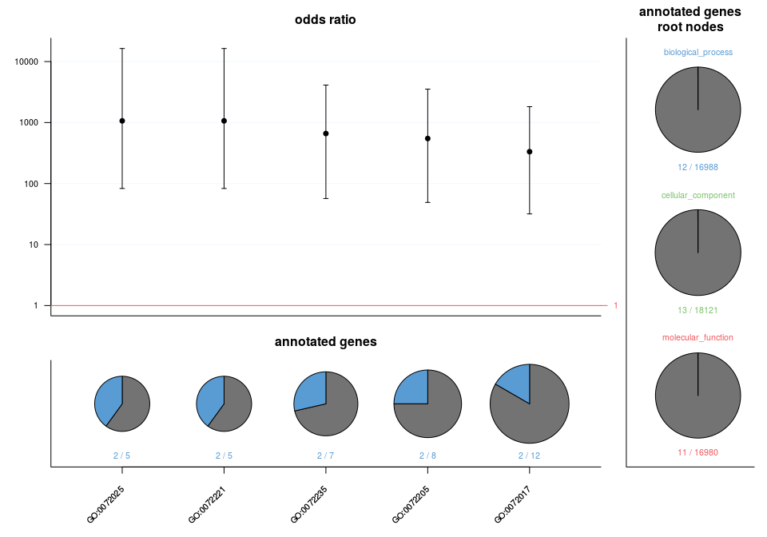

```r
plot_anno_scores(res_hyper, top_gos_hyper)
```

`plot_anno_scores` returns an invisible dataframe that contains the stats from Fisher’s exact test shown in the plot:

```r
## hypergeometric test with defined background
top_gos_hyper_bg = res_hyper_bg[[1]][1:5, 'node_id']
top_gos_hyper_bg
```

```
## [1] "GO:0005634" "GO:0005829" "GO:1901701" "GO:0032990" "GO:0048858"
```

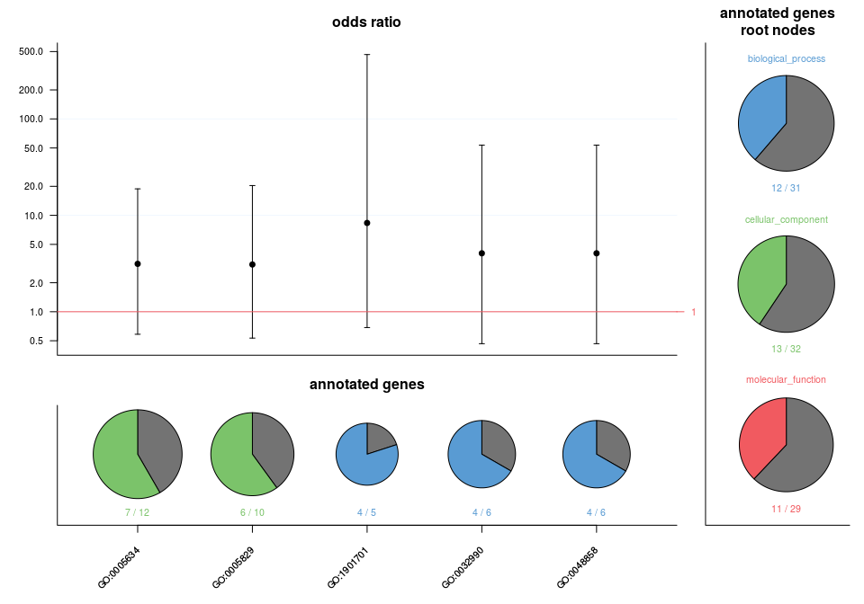

```r
plot_stats = plot_anno_scores(res_hyper_bg, top_gos_hyper_bg)
```

```r
plot_stats
```

```
##        go_id candi_genes bg_genes    root_id root_candi_genes root_bg_genes odds_ratio  ci95_low ci95_high
## 1 GO:0005634           7        5 GO:0005575               13            19   3.139089 0.5839891  18.82046
## 2 GO:0005829           6        4 GO:0005575               13            19   3.090603 0.5330266  20.38698
## 3 GO:1901701           4        1 GO:0008150               12            19   8.336770 0.6855418 465.68193
## 4 GO:0032990           4        2 GO:0008150               12            19   4.038635 0.4663523  53.56211
## 5 GO:0048858           4        2 GO:0008150               12            19   4.038635 0.4663523  53.56211
##            p
## 1 0.15024274
## 2 0.24393287
## 3 0.06001377
## 4 0.17350577
## 5 0.17350577
```

Note that `go_enrich` reports the hypergeometric test for over- and under-representation of candidate genes which correspond to the one-sided Fisher’s exact tests. Also keep in mind that the p-values from this table are not corrected for multiple testing.

For the **Wilcoxon rank-sum test** violin plots show the distribution of the scores of genes that are annotated to each GO-category and the root nodes. Horizontal lines in the left panel indicate the median of the scores that are annotated to the root nodes. The Wilcoxon rank-sum test reported in the `go_enrich` result compares the scores annotated to a GO-category with the scores annotated to the corresponding root node.

```r
## scores used for wilcoxon rank-sum test
top_gos_willi = res_willi[[1]][1:5, 'node_id']
# GO-categories with high scores
top_gos_willi
```

```
## [1] "GO:0005634" "GO:0036094" "GO:0098793" "GO:0030424" "GO:0044463"
```

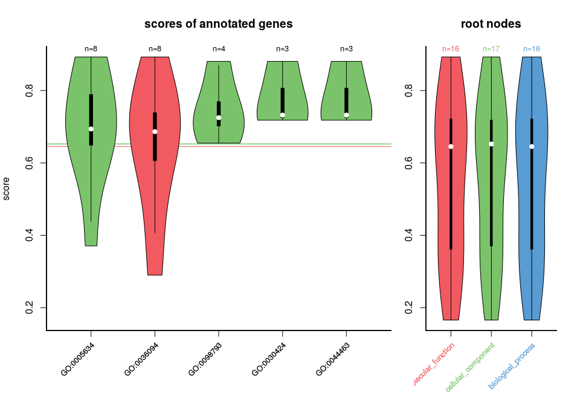

```r
plot_anno_scores(res_willi, top_gos_willi)
```

For the **binomial test** pie charts show the amounts of A and B counts associated with each GO-category and root node, (A in the colour of the corresponding root node). The top-panel shows point estimates and the 95%-CI of p(A) in the nodes, as well as horizontal lines that correspond to p(A) in the root nodes. The p-value in the returned object is based on the null hypothesis that p(A) in a node equals p(A) in the corresponding root node. Note that `go_enrich` reports that value for one-sided binomial tests.

```r
## counts used for the binomial test
top_gos_binom = res_binom[[1]][1:5, 'node_id']
# GO-categories with high proportion of A
top_gos_binom
```

```
## [1] "GO:0005536" "GO:0030246" "GO:0048029" "GO:0000166" "GO:1901265"
```

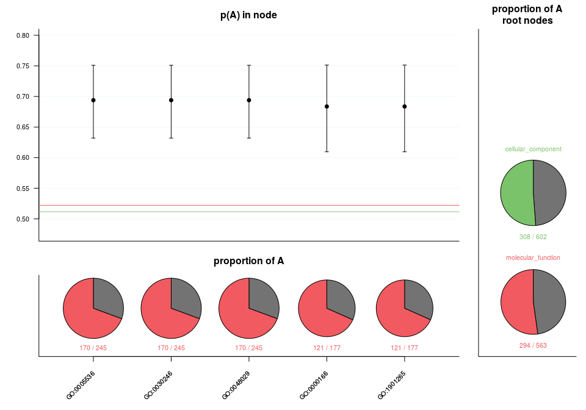

```r
plot_anno_scores(res_binom, top_gos_binom)
```

For the **2x2 contingency table test** pie charts show the proportions of A and B, as well as C and D counts associated with a GO-category. Root nodes are not shown, because this test is independent of the root category. The top panel shows the odds ratio and 95%-CI from Fisher’s exact test (two-sided) comparing A/B and C/D inside one node. Note that in `go_enrich`, if all four values are >=10, a chi-square test is performed instead of Fisher’s exact test.

```r
## counts used for the 2x2 contingency table test
top_gos_conti = res_conti[[1]][1:5, 'node_id']
# GO-categories with high A/B compared to C/D
top_gos_conti
```

```
## [1] "GO:1901135" "GO:0032553" "GO:0097367" "GO:0036094" "GO:0003824"
```

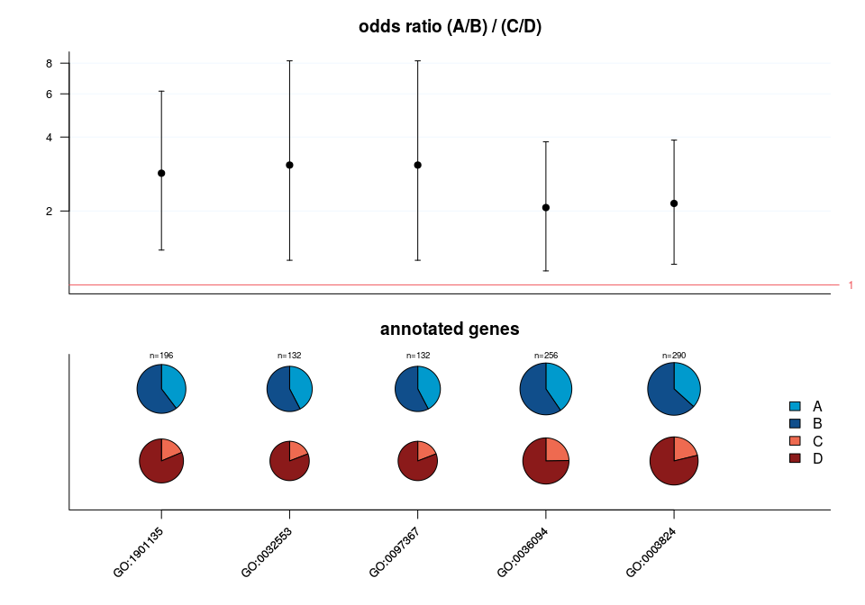

```r
plot_anno_scores(res_conti, top_gos_conti)
```

## 2.8 Explore the GO-graph

The functions `get_parent_nodes` and `get_child_nodes` can be used to explore the ontology-graph. They list all higher-level GO-categories and sub-GO-categories of input nodes, respectively, together with the distance between them:

```r
## get the parent nodes (higher level GO-categories) of two GO-IDs
get_parent_nodes(c('GO:0051082', 'GO:0042254'))
```

```
##   child_go_id parent_go_id                                   parent_name distance
## 1  GO:0042254   GO:0042254                           ribosome biogenesis        0
## 2  GO:0042254   GO:0022613          ribonucleoprotein complex biogenesis        1
## 3  GO:0042254   GO:0044085                 cellular component biogenesis        2
## 4  GO:0042254   GO:0071840 cellular component organization or biogenesis        3
## 5  GO:0042254   GO:0008150                            biological_process        4
## 6  GO:0051082   GO:0051082                      unfolded protein binding        0
## 7  GO:0051082   GO:0005515                               protein binding        1
## 8  GO:0051082   GO:0005488                                       binding        2
## 9  GO:0051082   GO:0003674                            molecular_function        3
```

```r
## get the child nodes (sub-categories) of two GO-IDs
get_child_nodes(c('GO:0090070', 'GO:0000112'))
```

```
##   parent_go_id child_go_id                                                         child_name distance
## 1   GO:0000112  GO:0000112                        nucleotide-excision repair factor 3 complex        0
## 2   GO:0000112  GO:0000440                         core TFIIH complex portion of NEF3 complex        1
## 3   GO:0090070  GO:0090070                         positive regulation of ribosome biogenesis        0
## 4   GO:0090070  GO:2000202       positive regulation of ribosomal subunit export from nucleus        1
## 5   GO:0090070  GO:2000234                             positive regulation of rRNA processing        1
## 6   GO:0090070  GO:2000205 positive regulation of ribosomal large subunit export from nucleus        2
## 7   GO:0090070  GO:2000208 positive regulation of ribosomal small subunit export from nucleus        2
```

Note that a GO-category per definition is also its own parent and child with distance 0.

The function `get_names` can be used to retrieve the names and root nodes of GO-IDs:

```r
## get the full names and domains of two GO-IDs
get_names(c('GO:0090070', 'GO:0000112'))
```

```
##        go_id                                     go_name          root_node
## 1 GO:0090070  positive regulation of ribosome biogenesis biological_process
## 2 GO:0000112 nucleotide-excision repair factor 3 complex cellular_component
```

It is also possible to go the other way round and search for GO-categories given part of their name using the function `get_ids`:

```r
## get GO-IDs of categories that contain 'blood-brain barrier' in their names
bbb = get_ids('blood-brain barrier')
head(bbb)
```

```
##                                                     node_name          root_node      go_id
## 1            establishment of endothelial blood-brain barrier biological_process GO:0014045
## 2          maintenance of permeability of blood-brain barrier biological_process GO:0035633
## 3                        establishment of blood-brain barrier biological_process GO:0060856
## 4                  establishment of glial blood-brain barrier biological_process GO:0060857
## 5          regulation of establishment of blood-brain barrier biological_process GO:0090210
## 6 positive regulation of establishment of blood-brain barrier biological_process GO:0090211
```

Note that this is just a `grep(..., ignore.case=TRUE)` on the node names of the ontology. More sophisticated searches, e.g. with regular expressions, could be performed on the table returned by `get_ids('')` which lists all non-obsolete GO-categories.

## 2.9 Retrieve associations between genes and GO-categories

`GOfuncR` also offers the functions `get_anno_genes` and `get_anno_categories` to get annotated genes given input GO-categories, and annotated GO-categories given input genes, respectively.  
`get_anno_genes` takes a vector of GO-IDs as input, and returns all genes that are annotated to those categories (using the default annotation package *Homo.sapiens*). The optional arguments `database` and `genes` can be used to define a different annotation package and the set of genes which is searched for annotations, respectively.  
This function implicitly includes annotations to child nodes.

```r
## find all genes that are annotated to GO:0000109
## using default database 'Homo.sapiens'
head(get_anno_genes(go_ids='GO:0000109'))
```

```
##        go_id   gene
## 1 GO:0000109  CETN2
## 2 GO:0000109 CHRAC1
## 3 GO:0000109  ERCC1
## 4 GO:0000109  ERCC4
## 5 GO:0000109  ERCC8
## 6 GO:0000109  POLD1
```

```r
## find out wich genes from a set of genes
## are annotated to some GO-categories
genes = c('AGTR1', 'ANO1', 'CALB1', 'GYG1', 'PAX2')
gos = c('GO:0001558', 'GO:0005536', 'GO:0072205', 'GO:0006821')
anno_genes = get_anno_genes(go_ids=gos, genes=genes)
# add the names and domains of the GO-categories
cbind(anno_genes ,get_names(anno_genes$go_id)[,2:3])
```

```
##        go_id  gene                                 go_name          root_node
## 1 GO:0001558 AGTR1               regulation of cell growth biological_process
## 2 GO:0006821  ANO1                      chloride transport biological_process
## 3 GO:0072205 CALB1 metanephric collecting duct development biological_process
## 4 GO:0072205  PAX2 metanephric collecting duct development biological_process
```

```r
## find all mouse-gene annotations to two GO-categories
## ('Mus.musculus' has to be installed)
gos = c('GO:0072205', 'GO:0000109')
head(get_anno_genes(go_ids=gos, database='Mus.musculus'))
```

`get_anno_categories` on the other hand uses gene-symbols as input and returns associated GO-categories:

```r
## get the GO-annotations for two random genes
anno = get_anno_categories(c('BTC', 'SPAG5'))
head(anno)
```

```
##   gene      go_id
## 1  BTC GO:0000165
## 2  BTC GO:0004713
## 3  BTC GO:0005088
## 4  BTC GO:0005154
## 5  BTC GO:0005515
## 6  BTC GO:0005576
```

```r
## get the GO-annotations for two mouse genes
## ('Mus.musculus' has to be installed)
anno_mus = get_anno_categories(c('Mus81', 'Papola'), database='Mus.musculus')
```

This function only returns direct annotations. To get also the parent nodes of the GO-categories a gene is annotated to, the function `get_parent_nodes` can be used:

```r
# get all direct annotations of NXPH4
direct_anno = get_anno_categories('NXPH4')
direct_anno
```

```
##    gene      go_id
## 1 NXPH4 GO:0003674
## 2 NXPH4 GO:0005102
## 3 NXPH4 GO:0005575
## 4 NXPH4 GO:0005576
## 5 NXPH4 GO:0007218
```

```r
# get parent nodes of directly annotated GO-categories
parent_ids = unique(get_parent_nodes(direct_anno$go_id)[,2])
# add GO-domain
full_anno = get_names(parent_ids)
head(full_anno)
```

```
##        go_id              go_name          root_node
## 1 GO:0003674   molecular_function molecular_function
## 2 GO:0005102     receptor binding molecular_function
## 3 GO:0005515      protein binding molecular_function
## 4 GO:0005488              binding molecular_function
## 5 GO:0005575   cellular_component cellular_component
## 6 GO:0005576 extracellular region cellular_component
```

# 3 Schematics

### 3.0.1 Schematic 1: Hypergeometric test and FWER calculation

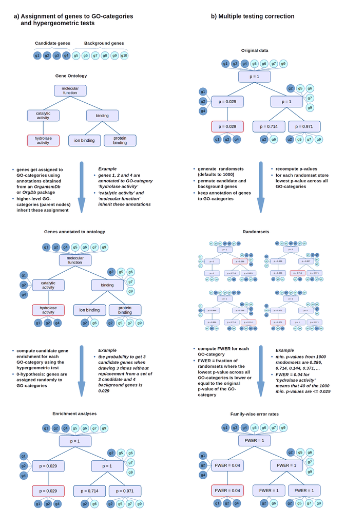

The FWER for the other tests is computed in the same way: the gene-associated variables (scores or counts) are permuted while the annotations of genes to GO-categories stay fixed. Then the statistical tests are evaluated again for every GO-category.

### 3.0.2 Schematic 2: `circ_chrom` option for genomic regions input

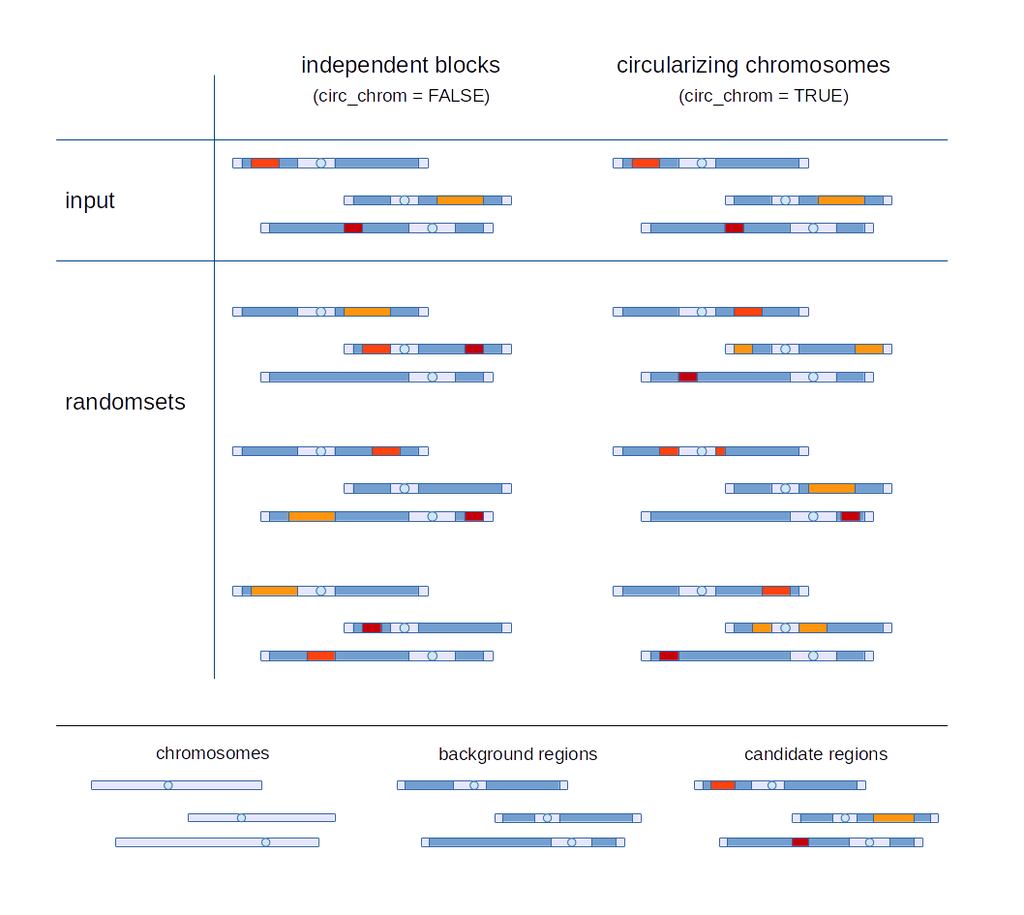

To use genomic regions as input, the first column of the `genes` input dataframe has to be of the form `chr:start-stop` and `regions=TRUE` has to be set. The option `circ_chrom` defines how candidate regions are randomly moved inside the background regions for computing the FWER. When `circ_chrom=FALSE` (default), candidate regions can be moved to any background region on any chromosome, but are not allowed to overlap multiple background regions. When `circ_chrom=TRUE`, candidate regions are only moved on the same chromosome and are allowed to overlap multiple background regions. The chromosome is ‘circularized’ which means that a randomly placed candidate region may start at the end of the chromosome and continue at the beginning.

# 5 References

[1] Ashburner, M. et al. (2000). Gene Ontology: tool for the unification of biology. Nature Genetics 25: 25-29. [doi:10.1038/75556]

[2] Pruefer, K. et al. (2007). FUNC: A package for detecting significant associations between gene sets and ontological annotations, BMC Bioinformatics 8: 41. [doi:10.1186/1471-2105-8-41]

[3] McDonald, J. H. Kreitman, M. (1991). Adaptive protein evolution at the Adh locus in Drosophila, Nature 351: 652-654. [doi:10.1038/351652a0]